# Data Science Project 1

SOLUTIONS / Jill E. Thomley

Updated: Tuesday, March 26, 2019 @ 03:29:24 PM

```r
title: 'Data Science Project 1'
author: 'SOLUTIONS / Jill E. Thomley'
date: 'Updated: `r format(Sys.time(), "%A, %B %d, %Y @ %X")`'
output:
  html_document:
    theme: yeti
    highlight: textmate
    toc: true
    toc_float: false
    toc_depth: 4
    code_folding: hide
```

```r
# Load all packages here
library(tidyverse)
library(ggthemes)
library(moderndive)
```

```r
# Read in datasets here
co2_monthly <-
  read.table(file = url("ftp://aftp.cmdl.noaa.gov/products/trends/co2/co2_mm_mlo.txt"),
             col.names = c("year", "month", "date", "mean_co2", "int_mean_co2", "trend_mean_co2", "numdays")) %>%
  mutate(decade = case_when(year %in% 1950:1959 ~ "1950s",
                            year %in% 1960:1969 ~ "1960s",
                            year %in% 1970:1979 ~ "1970s",
                            year %in% 1980:1989 ~ "1980s",
                            year %in% 1990:1999 ~ "1990s",
                            year %in% 2000:2009 ~ "2000s",
                            year %in% 2010:2019 ~ "2010s"))

co2_annual <-
  read.table(file = url("ftp://aftp.cmdl.noaa.gov/products/trends/co2/co2_annmean_mlo.txt"),
             col.names = c("year", "mean_co2", "uncertainty")) %>%
  mutate(decade = case_when(year %in% 1950:1959 ~ "1950s",
                            year %in% 1960:1969 ~ "1960s",
                            year %in% 1970:1979 ~ "1970s",
                            year %in% 1980:1989 ~ "1980s",
                            year %in% 1990:1999 ~ "1990s",
                            year %in% 2000:2009 ~ "2000s",
                            year %in% 2010:2019 ~ "2010s"))

anthro <- read_csv("https://raw.githubusercontent.com/STAT-JET-ASU/Datasets/master/Instructor/anthropometric.csv")
```

### MAUNA LOA CO<sub>2</sub> MODELING AND VISUALIZATION

#### The Question

In 1966, the World Meteorological Organization (WMO) put forth the term “climatic change” to refer to climatic variability on time-scales longer than ten years, regardless of the cause for such change. During the next decade, scientists began to suspect that human activities had the potential to drastically alter the global climate in ways that would have negative impacts on our environment. The term evolved into “climate change” and is now used to describe both the process of change and the perceived problem. Sometimes the term “global warming” is used, though in many ways this fails to adequately describe the variability in impact, since climate change can cause both hot and cold extremes in weather. *Anthropogenic* climate change is change that is caused by human activity, as opposed to the Earth’s natural processes. However, in the context of environmental policy, the term “climate change” is often used to mean anthropogenic climate change.

Mauna Loa Observatory is a world-renowned atmospheric research facility. It has been continuously monitoring and collecting data since the 1950’s and its remote location makes it very well-suited for monitoring atmospheric components that can contribute to climate change, including the heat-trapping greenhouse gas carbon dioxide (CO<sub>2</sub>). Carbon overload from burning fossil fuels and deforestation is cited as the primary cause of anthropogenic climate change by proponents of such theories, while opponents assert that natural process (such as photosynthesis) contribute more to atmospheric CO<sub>2</sub> than humans and observed changes are simply Earth’s cycle.

#### Monthly Mean CO<sub>2</sub>: The Last Five Years

Create your own version of the plot found [here](https://www.esrl.noaa.gov/gmd/ccgg/trends/index.html). Do not replicate it, but rather design your own. Use one of the themes found in the `ggplot2` or `ggthemes` packages. You are encouraged to make style adjustments to help you informatively display the data.

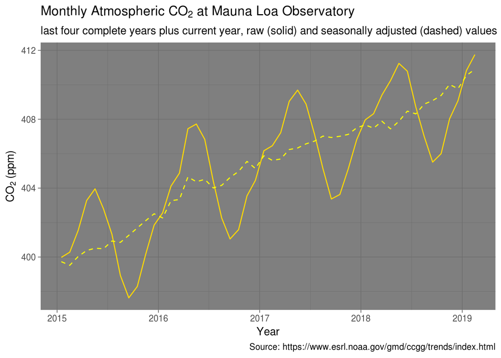

```r
ggplot(filter(co2_monthly, year >= 2015)) +
  geom_line(aes(x = date, y = int_mean_co2), color = "gold") +
  geom_line(aes(x = date, y = trend_mean_co2), color = "yellow", linetype = "dashed") +
  labs(title = expression("Monthly Atmospheric CO"[2]*" at Mauna Loa Observatory"),
       subtitle = "last four complete years plus current year, raw (solid) and seasonally adjusted (dashed) values",
       x = "Year",
       y = expression("CO"[2]*" (ppm)"),
       caption = "Source: https://www.esrl.noaa.gov/gmd/ccgg/trends/index.html") +
  theme_dark()
```

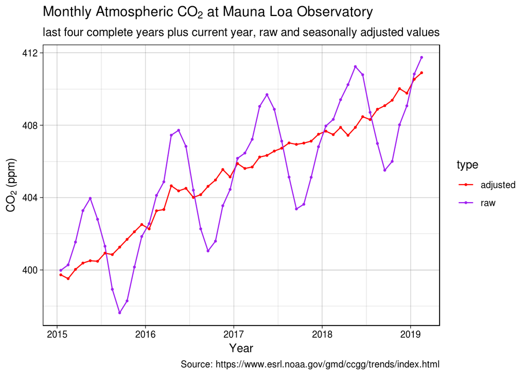

```r
co2_monthly %>%
  filter(year >= 2015) %>%
  gather(type, co2, c(int_mean_co2, trend_mean_co2)) %>%
  select(year, date, type, co2) %>%
  mutate(type = ifelse(type == "int_mean_co2", "raw", "adjusted")) %>%
  ggplot(aes(x = date, y = co2, color = type)) +
  geom_line() +
  geom_point(size = .6) +
  labs(title = expression("Monthly Atmospheric CO"[2]*" at Mauna Loa Observatory"),
       subtitle = "last four complete years plus current year, raw and seasonally adjusted values",
       x = "Year",
       y = expression("CO"[2]*" (ppm)"),
       caption = "Source: https://www.esrl.noaa.gov/gmd/ccgg/trends/index.html") +
  theme_linedraw() +
  scale_color_manual(values = c("red", "purple"))
```

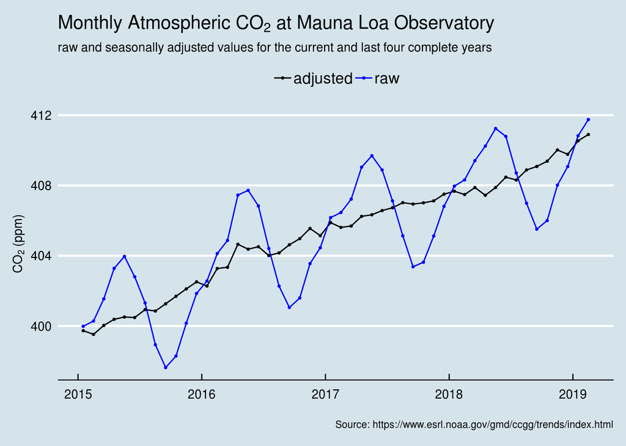

```r
co2_monthly %>%
  filter(year >= 2015) %>%
  gather(type, co2, c(int_mean_co2, trend_mean_co2)) %>%
  select(year, date, type, co2) %>%
  mutate(type = ifelse(type == "int_mean_co2", "raw", "adjusted")) %>%
  ggplot(aes(x = date, y = co2, color = type)) +
  geom_line() +
  geom_point(size = .6) +
  labs(title = expression("Monthly Atmospheric CO"[2]*" at Mauna Loa Observatory"),
       subtitle = "raw and seasonally adjusted values for the current and last four complete years",
       x = "",
       y = expression("CO"[2]*" (ppm)"),
       caption = "Source: https://www.esrl.noaa.gov/gmd/ccgg/trends/index.html") +
  theme_economist() +
  theme(legend.title = element_blank()) +
  scale_color_manual(values = c("black", "blue"))
```

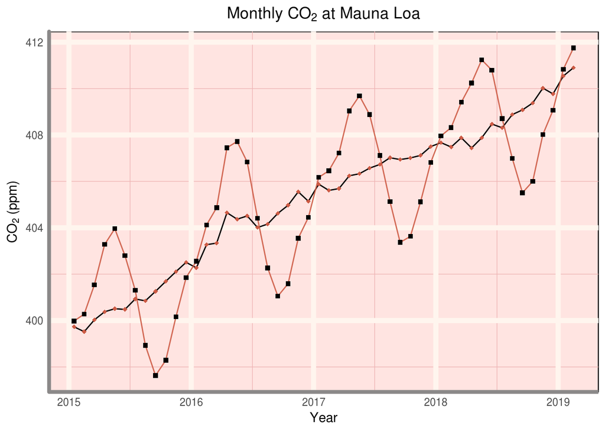

```r
# Adapted student example with theme modification
# Which theme element controls each plot feature?

co2_monthly %>% filter(year >= 2015) %>%
  ggplot() +
  geom_line(aes(x = date, y = trend_mean_co2), col = "black") +
  geom_point(aes(x = date, y = trend_mean_co2), col = "coral3", shape = 18) +
  geom_line(aes(x = date, y = int_mean_co2), col = "coral3", alpha = .90) +
  geom_point(aes(x = date, y = int_mean_co2), col = "black", shape = 15) +
  labs(title = expression("Monthly CO"[2]*" at Mauna Loa"),
       y = expression("CO"[2]*" (ppm)"),
       x = "Year") +
  theme_minimal() +
  theme(plot.title = element_text(hjust = 0.5),
        panel.background = element_rect(fill = 'mistyrose1'),
        panel.grid.major = element_line(colour = "seashell1", size = 2),
        panel.grid.minor = element_line(colour = "rosybrown2", size = .25, linetype = "solid"),
        panel.border = element_blank(),
        axis.line.x = element_line(colour = "snow4", size = 1.5, lineend = "butt"),
        axis.line.y = element_line(colour = "snow4", size = 1.5))
```

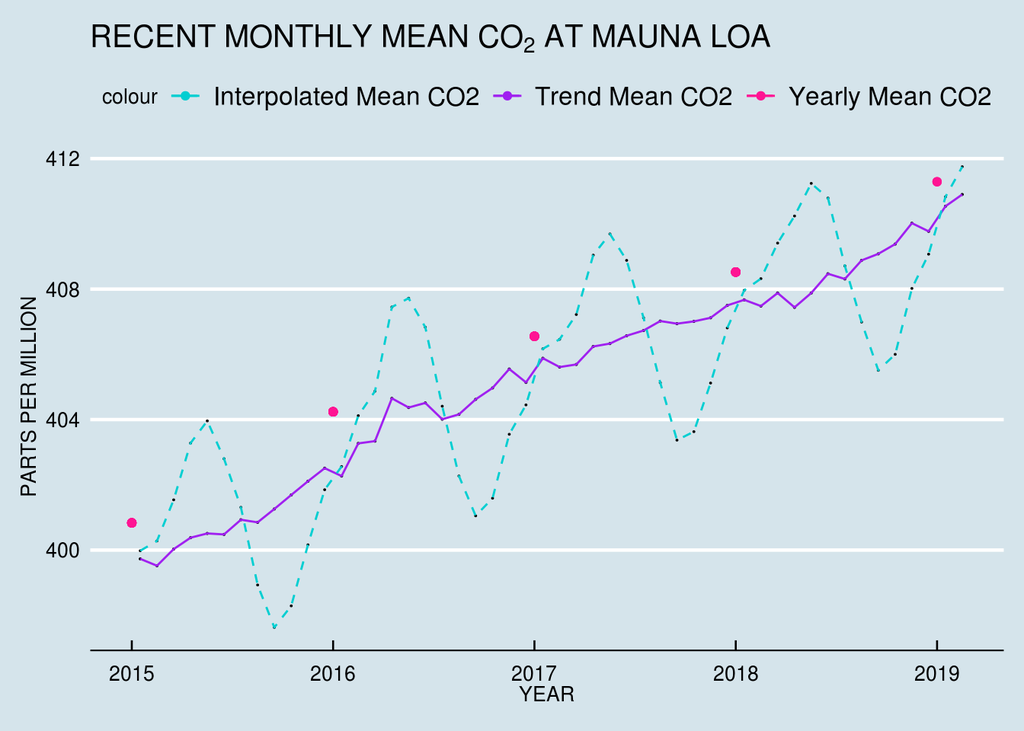

```r
# Adapted student example with additional data
# Also shows how to get a legend without gather

newcdata <- co2_monthly %>%
  group_by(year) %>%
  mutate(meanc = mean(int_mean_co2)) %>%
  filter(year >= 2015)

ggplot(data = filter(co2_monthly, year >= 2015)) +
  geom_point(aes(x = date, y = trend_mean_co2), size = .05) +
  geom_line(aes(x = date, y = trend_mean_co2, color = "Trend Mean CO2")) +
  geom_point(aes(x = date, y = int_mean_co2), size = .01) +
  geom_line(aes(x = date, y = int_mean_co2, color = "Interpolated Mean CO2"), linetype = 2) +
  geom_point(data = newcdata, aes(x = year, y = meanc, col = "Yearly Mean CO2")) +
  ggtitle(expression("RECENT MONTHLY MEAN CO"[2]*" AT MAUNA LOA")) +
  ylab("PARTS PER MILLION") +
  xlab("YEAR") +
  theme_economist() +
  scale_color_manual(values = c("darkturquoise", "purple", "deeppink"))
```

#### Monthly Mean CO<sub>2</sub>: A Major Milestone

An atmospheric CO<sub>2</sub> level of 400 ppm is considered by many to be a symbolic threshold with regard to climate change. “In the centuries to come, history books will likely look back on September 2016 as a major milestone for the world’s climate. At a time when atmospheric carbon dioxide is usually at its minimum, the monthly value failed to drop below 400 parts per million.” ([source](https://www.scientificamerican.com/article/earth-s-co2-passes-the-400-ppm-threshold-maybe-permanently/))

Adapt your plot above to include a red dashed line at 400 ppm and a large red dot on September 2016, with appropriate annotations to indicate what these additions represent.

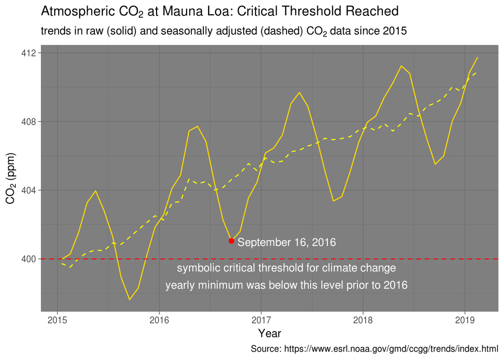

```r
ggplot(filter(co2_monthly, year >= 2015)) +
  geom_line(aes(x = date, y = int_mean_co2), color = "gold") +
  geom_line(aes(x = date, y = trend_mean_co2), color = "yellow", linetype = "dashed") +
  geom_hline(yintercept = 400, color = "red", linetype = "dashed") +
  labs(title = expression("Atmospheric CO"[2]*" at Mauna Loa: Critical Threshold Reached"),
       subtitle = expression("trends in raw (solid) and seasonally adjusted (dashed) CO"[2]*" data since 2015"),
       x = "Year",
       y = expression("CO"[2]*" (ppm)"),
       caption = "Source: https://www.esrl.noaa.gov/gmd/ccgg/trends/index.html") +
  theme_dark() +
  geom_point(filter(co2_monthly, year == 2016, month == 9),
             mapping = aes(x = date, y = int_mean_co2),
             color = "red", size = 2) +
  annotate("text", x = 2017.25, y = 401,
           label = "September 16, 2016", color = "white") +
  annotate("text", x = 2017.25, y = 399.5,
           label = "symbolic critical threshold for climate change", color = "white") +
  annotate("text", x = 2017.25, y = 398.5,
           label = "yearly minimum was below this level prior to 2016", color = "white")
```

#### Trends Over Time in CO<sub>2</sub> Growth

Consider the full Mauna Loa CO<sub>2</sub> record found [here](https://www.esrl.noaa.gov/gmd/ccgg/trends/full.html). The overall trend is not linear, but segments of it may be piecewise linear. Filter to remove the incomplete decades 1950s and 2010s and create a scatterplot that shows the interpolated CO<sub>2</sub> values with a fitted linear model for each remaining decade. Do not include standard error bands.

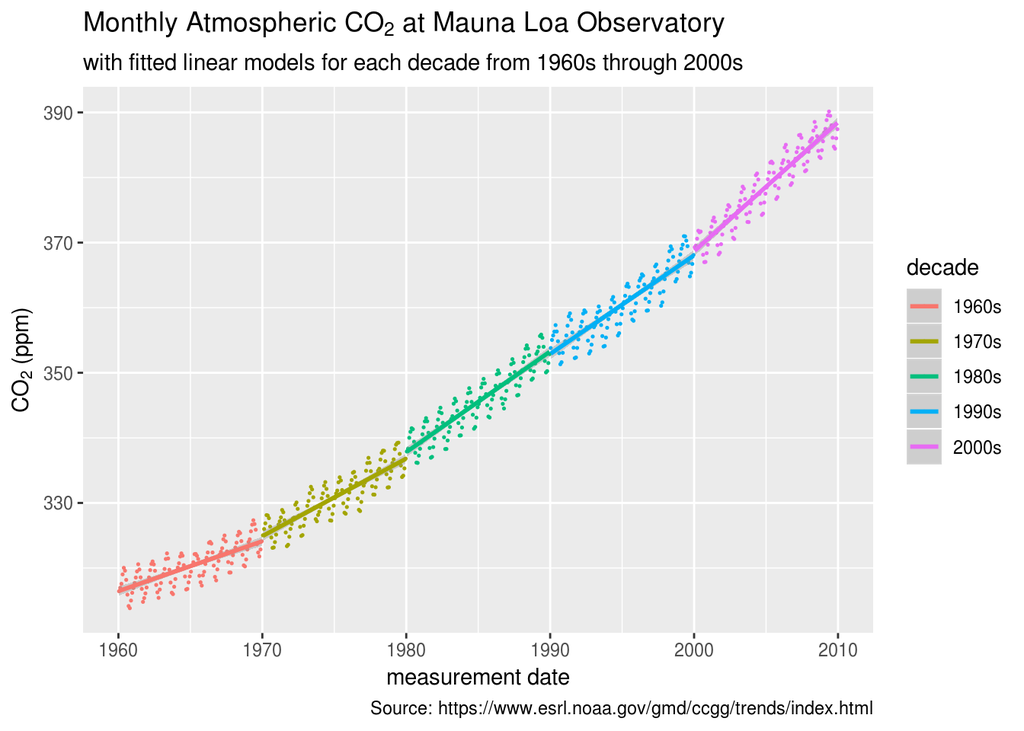

```r
ggplot(filter(co2_monthly, !decade %in% c("1950s", "2010s")),
       aes(x = date, y = int_mean_co2, color = decade)) +
  geom_point(size = 0.25) +
  geom_smooth(method = "lm") +
  labs(title = expression("Monthly Atmospheric CO"[2]*" at Mauna Loa Observatory"),
       subtitle = "with fitted linear models for each decade from 1960s through 2000s",
       x = "measurement date",
       y = expression("CO"[2]*" (ppm)"),
       caption = "Source: https://www.esrl.noaa.gov/gmd/ccgg/trends/index.html")
```

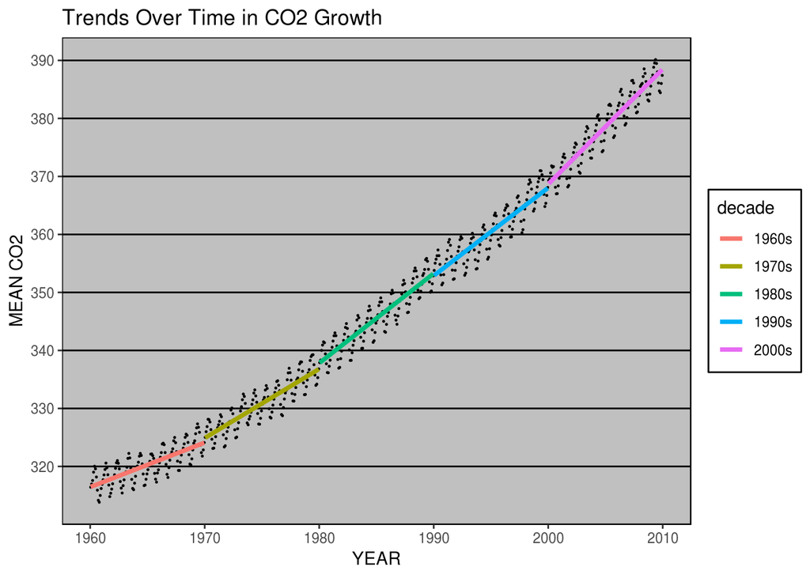

```r
# Adapted from a student example

filter(co2_monthly, year >= 1960, year < 2010) %>%
  ggplot() +
    geom_point(aes(date, int_mean_co2), size = 0.2) +
    geom_smooth(aes(date, int_mean_co2, color = decade), method = "lm", se = FALSE, size = 1.3) +
    scale_x_continuous(breaks = seq(1960, 2020, 10)) +
    scale_y_continuous(breaks = seq(300, 400, 10)) +
    labs(title = "Trends Over Time in CO2 Growth",
         x = "YEAR",
         y = "MEAN CO2") +
    theme_excel()
```

#### Annual Mean CO<sub>2</sub> Since 1959

Replicate as closely as possible the annual mean plot found [here](https://github.com/STAT-JET-ASU/DataScience1/blob/master/Projects/annualCO2plot.png). Hint: It uses a `ggplot` theme for some of the formatting.

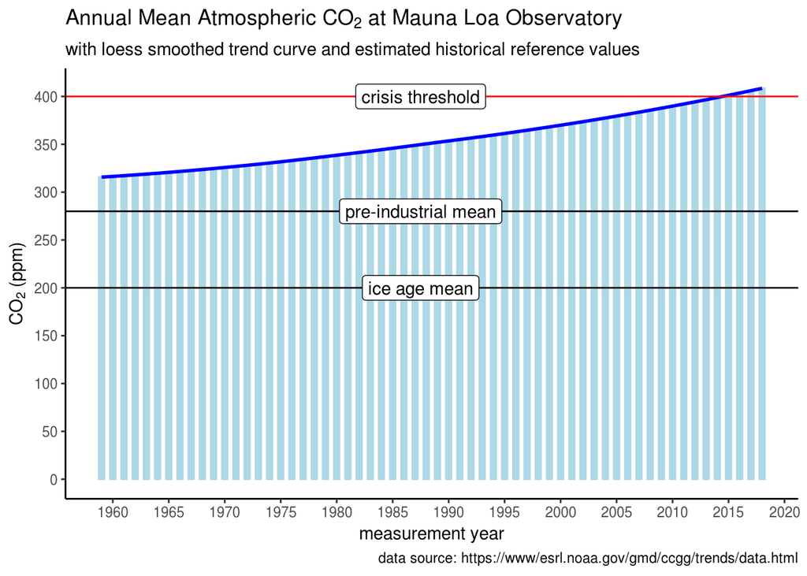

```r
ggplot(co2_annual, aes(x = year, y = mean_co2)) +
  geom_bar(stat = "identity", width = 0.5, fill = "lightblue", color = "lightblue") +
  geom_smooth(color = "blue") +
  scale_x_continuous(breaks = seq(1960, 2020, 5)) +
  scale_y_continuous(breaks = seq(0, 400, 50)) +
  labs(title = expression("Annual Mean Atmospheric CO"[2]*" at Mauna Loa Observatory"),
       subtitle = "with loess smoothed trend curve and estimated historical reference values",
       x = "measurement year",
       y = expression("CO"[2]*" (ppm)"),
       caption = "data source: https://www/esrl.noaa.gov/gmd/ccgg/trends/data.html") +
  geom_hline(yintercept = c(200, 280, 400),
             color = c("black", "black", "red")) +
  annotate("label", x = 1987.5,
           y = c(200, 280, 400),
           label = c("ice age mean", "pre-industrial mean", "crisis threshold")) +
  theme_classic()
```

#### Discussion

In what way could these visualizations be used to support the theory of anthropogenic climate change?

**ANSWER:** There is a non-linearly increasing trend in atmospheric CO<sub>2</sub>. The difference between the pre-industrial mean and values in 2015 and beyond is larger than the difference between the ice age and pre-industrial means. In fact, it looks like the rise within the Mauna Loa record is approximatwely the same as the difference between the ice age and pre-industrial means. This suggests that industrialization (i.e., human activity) might be contributing to a historically rapid increase in atmospheric CO<sub>2</sub>.

Why are data such as these considered *evidence* rather than *proof* of anthropogenic climate change?

**ANSWER:** These data are the results of a long-term observational study rather a controlled experiment. The historical values prior to the late 1950s are estimates based on secondary samples and statistical models rather than direct observation. Association is not causation. There are too many missing and confounding variables that could offer alternative explanations for some or all of the observed trends.

### ANTHROPOMETRIC MODELING AND VISUALIZATION

#### The Question

Are people generally happy with their heights? If not, how tall do they want to be? Dr. Thomley’s [anthropometric](https://stat-jet-asu.github.io/Datasets/InstructorDescriptions/anthropometric.html) dataset contains measurements of students’ heights and their self-selected ideal heights. You will fit a parallel slopes model to predict ideal height using measured height and gender, then interpret the results of your model.

#### Exploratory Data Analysis

Filter the dataset to include only students who self-identified as male or female (there are not enough data points in the other categories to create a model for them). Perform EDA to determine whether you need to perform any transformations or remove any data points before you fit your model. Explain your rationale for any transformations or deletions you chose to make in the dataset.

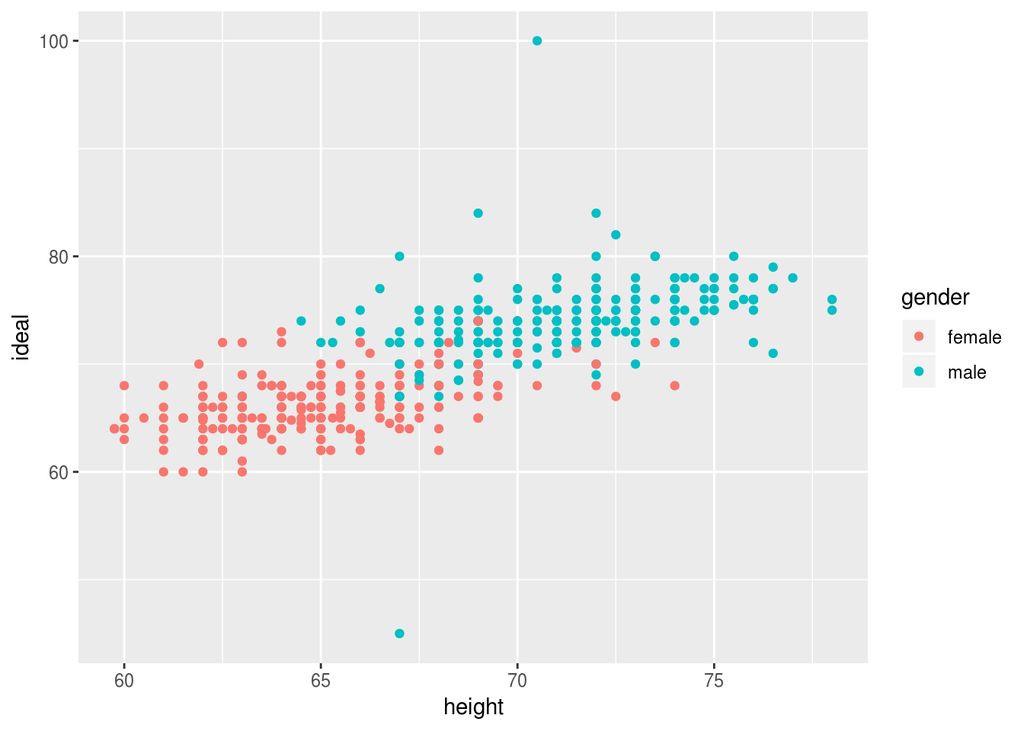

```r
anthro_fm <- anthro %>% filter(gender %in% c("female", "male"))

ggplot(anthro_fm, aes(x = height, y = ideal, color = gender)) + geom_point()
```

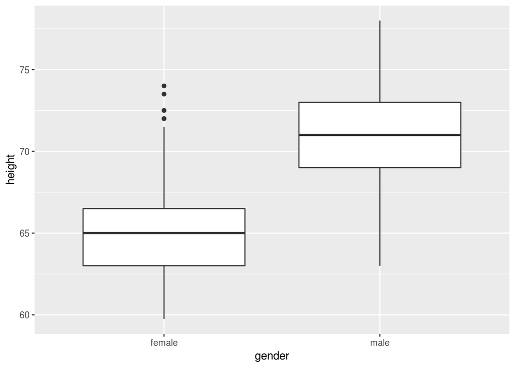

```r
ggplot(anthro_fm, aes(x = gender, y = height)) + geom_boxplot()
```

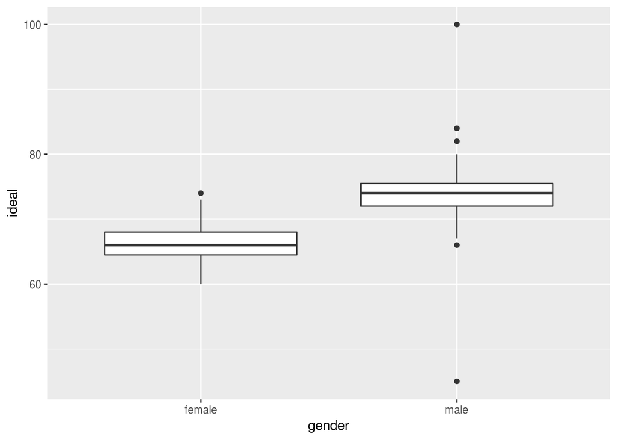

```r
ggplot(anthro_fm, aes(x = gender, y = ideal)) + geom_boxplot()
```

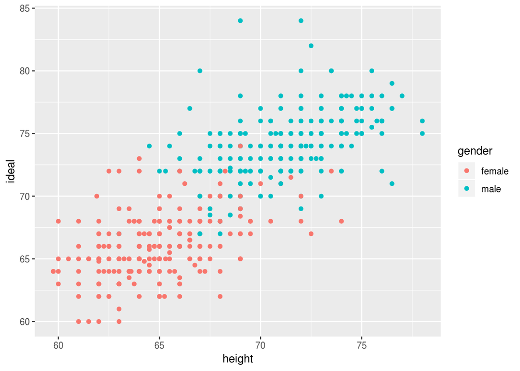

```r
anthro_fm_mod <- anthro_fm %>% filter(ideal > 55, ideal < 85)

ggplot(anthro_fm_mod, aes(x = height, y = ideal, color = gender)) + geom_point()
```

#### Fitting the Model

Create a scatterplot of ideal height versus measured height showing separate fitted linear models for males and females. Then fit a parallel slopes model with measured height and gender as predictors and save it as `ideal_model`. Display its summary.

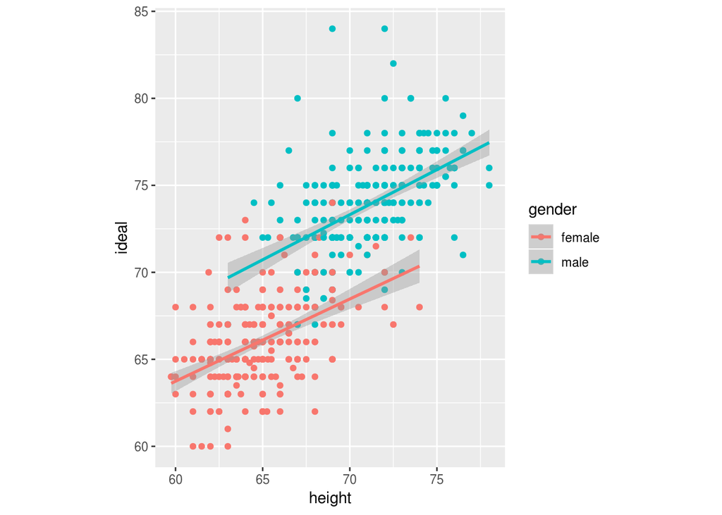

```r
ggplot(anthro_fm_mod, aes(x = height, y = ideal, color = gender)) +
  geom_point() +
  geom_smooth(method = "lm") +
  coord_fixed()
```

```r
ideal_model <- lm(ideal ~ height + gender, data = anthro_fm_mod)
summary(ideal_model)
```

```
Call:
lm(formula = ideal ~ height + gender, data = anthro_fm_mod)

Residuals:
    Min      1Q  Median      3Q     Max
-5.5953 -1.3357 -0.1049  1.1675 11.1611

Coefficients:
            Estimate Std. Error t value Pr(>|t|)
(Intercept) 33.81289    2.37120   14.26   <2e-16 ***
height       0.49680    0.03643   13.64   <2e-16 ***
gendermale   4.74680    0.29744   15.96   <2e-16 ***
---
Signif. codes:  0 '***' 0.001 '**' 0.01 '*' 0.05 '.' 0.1 ' ' 1

Residual standard error: 2.259 on 534 degrees of freedom
Multiple R-squared:  0.7703,    Adjusted R-squared:  0.7694
F-statistic: 895.1 on 2 and 534 DF,  p-value: < 2.2e-16
```

#### Examine Residuals

Create a residual scatterplot and histogram for your model.

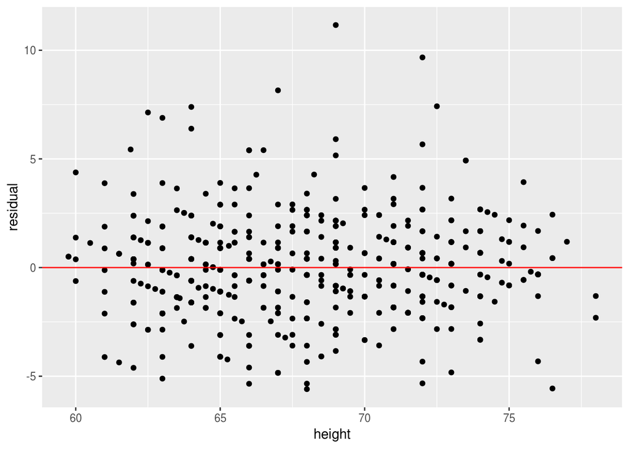

```r
ggplot(get_regression_points(ideal_model), aes(x = height, y = residual)) +
  geom_point() +
  geom_hline(yintercept = 0, color = "red")
```

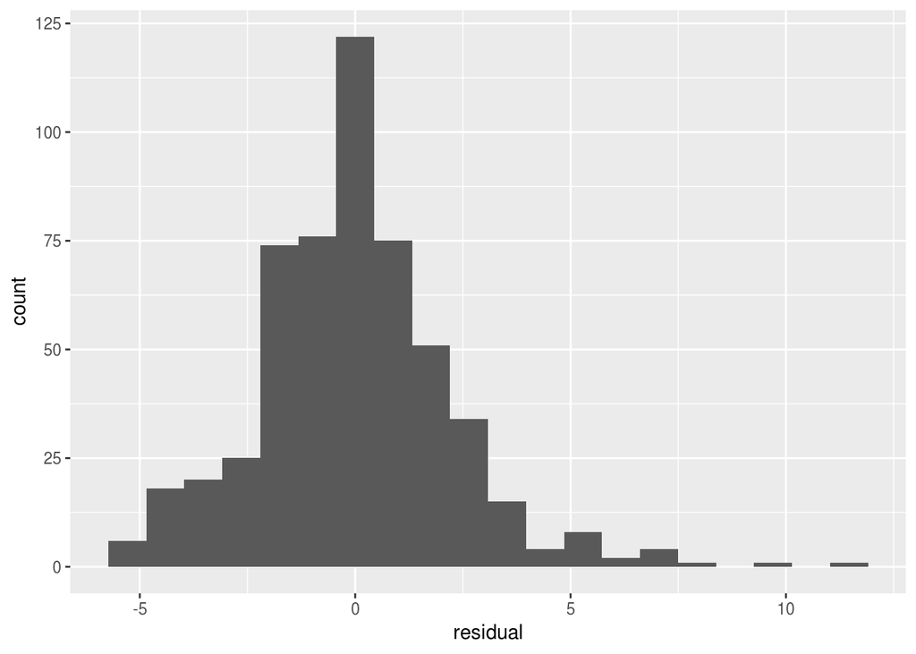

```r
ggplot(get_regression_points(ideal_model), aes(x = residual)) +
  geom_histogram(bins = 20)
```

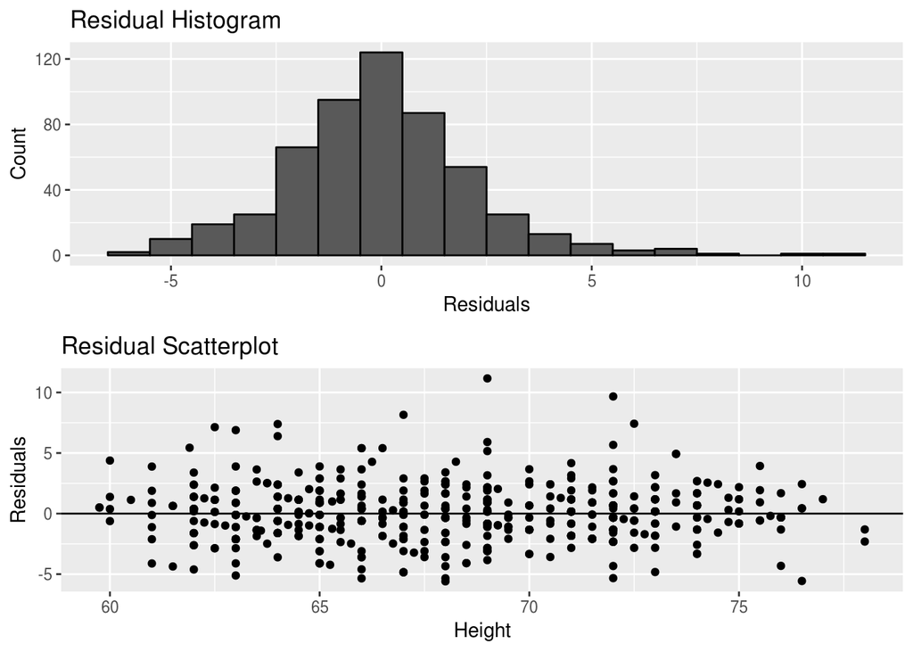

```r
# Adapted student version
# Invoking the package gridExtra inline means
# that it does not show up in the sessionInfo

gridExtra::grid.arrange(
get_regression_points(ideal_model) %>%
  ggplot(aes(x = residual)) +
  geom_histogram(binwidth = 1, color = "black") +
  labs(title = "Residual Histogram",
       x = "Residuals",
       y = "Count"),

get_regression_points(ideal_model) %>%
  ggplot(aes(height, residual)) +
  geom_hline(yintercept = 0) +
  geom_point() +
    labs(title = "Residual Scatterplot",
       x = "Height",
       y = "Residuals"),
nrow = 2)
```

#### Predicting Ideal Height

Create a dataset containing heights at one-inch intervals from 60 to 80 for each gender. Use your parallel slopes model to predict the ideal heights for these values. Use `mutate` to create a new variable in your results `tibble` that shows whether the ideal height is less than, equal to, or greater than height. The `case_when` function may be useful here. Display the results.

```r
pred_dataset <- tibble(height = rep(60:80, 2), gender = (rep(c("male", "female"), c(21, 21))))
results <- get_regression_points(ideal_model, newdata = pred_dataset) %>%
  mutate(compare = case_when(ideal_hat < height ~ "less than",
                             ideal_hat == height ~ "equal",
                             ideal_hat > height ~ "greater than"))
print.data.frame(results)
```

```
   ID height gender ideal_hat      compare
1   1     60   male    68.368 greater than
2   2     61   male    68.864 greater than
3   3     62   male    69.361 greater than
4   4     63   male    69.858 greater than
5   5     64   male    70.355 greater than
6   6     65   male    70.852 greater than
7   7     66   male    71.348 greater than
8   8     67   male    71.845 greater than
9   9     68   male    72.342 greater than
10 10     69   male    72.839 greater than
11 11     70   male    73.336 greater than
12 12     71   male    73.832 greater than
13 13     72   male    74.329 greater than
14 14     73   male    74.826 greater than
```

[output cut: 28 more lines]

#### Additional Visualization

Create a plot that shows the same fitted lines for males and females as your scatterplot (but without points), as well as an annotated line indicating the relationship ideal height = measured height. Format this line in some way other than the default (e.g., color, style).

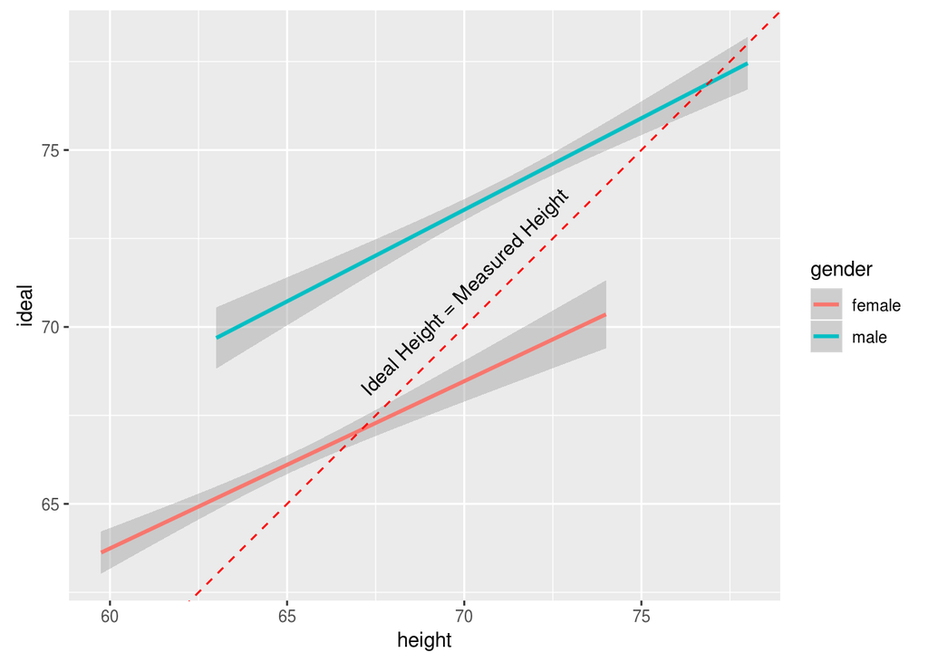

```r
ggplot(anthro_fm_mod, aes(x = height, y = ideal, color = gender)) +
  geom_smooth(method = "lm") +
  geom_abline(intercept = 0, slope = 1, color = "red", linetype = "dashed") +
  annotate("text", x = 70, y = 71, angle = 45, label = "Ideal Height = Measured Height") +
  coord_fixed()
```

#### Discussion

Explain your rationale for any transformations or deletions you chose to make in the dataset.

**ANSWER:** I removed the points that seemed to be extreme outliers on the male ideal height boxplot, which also seem to be large bivate outliers on the scatterplot. Although there were other outliers on the boxplots, they were much closer to the whiskers and appeared to follow the general bivariate pattern more closely. (*Other answers are possible here. Some people may choose to remove additional ideal heights over 80 inches, for example.*)

Does the model seem appropriate for the data? Be sure to include discussion of the residuals.

**ANSWER:** In the scatterplot, the fitted lines for males and females appear to be reasonably parallel. In the scatterplot of residuals, there is no patterned deviation from randomness around the residual = 0 line (e.g., no megaphone or U-shape). The histogram of residuals shows a slightly longer tail on the right than the left, but there is no serious skew or multimodality. The differences in the tails may be due to random variation in the sample.

Do the people in this sample generally seem to be happy with their heights or do their ideal heights differ? Do males and females seem to have the same attitudes regarding what is an ideal height? What group patterns do you notice? Discuss.

**ANSWER:** No, people do not generally seem to be happy with their heights. On average, men always seem to want to be taller until they reach about 77 inches in height. The shorter they are, the taller they typically want to be. Women who are around 67 inches seem reasonably happy. Those who are shorter tend to want to be taller, and those taller tend to want to be shorter. We can see these patterns in both the predicted values and plots.